# Coursera Data Science Capstone - Predict next word.

## The Objective

The main goal of this project is to build a shiny app that is able to predict next word.

Data has been downloaded from https://d396qusza40orc.cloudfront.net/dsscapstone/dataset/Coursera-SwiftKey.zip.

The data consists of three data frame sets- en_US Blogs, en_US News and en_US twitter

## Approach

- After loading the data, a sample of 50% of the data from each of the files was created, cleansed and tokenized to be used as a corpous of text. Data was converted to lowercase, removed punctuation, whitespace and numbers.
- The sample text was tokenized using n-gram to build the predictive model.
- The n-gram files - Unigram(single word), Bigram(two words) and Trigram(three words) are matrices with frequencies of words used in the alogrithm to predict the next word.

## Shiny Application

- The Shiny application allows the prediction of the next possible word in a sentence.
- The user enter's the text in an input box, and the application returns the most likely word to be used.
- The predicted word is obtained from the n-grams matrices, comparing it with tokenized frequency of 2 and 3 grams sequences.

## Screenshot of the Shiny Appy

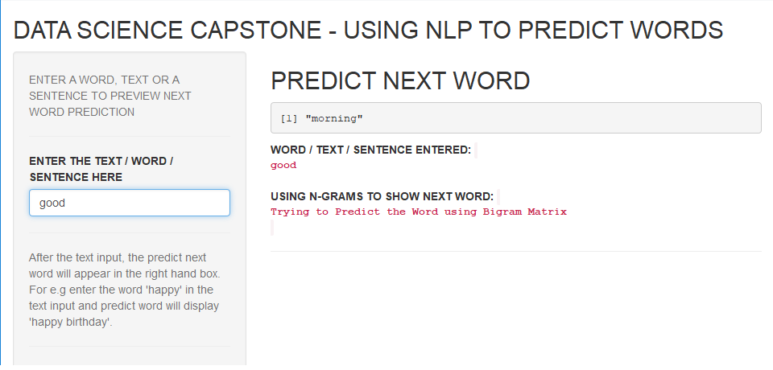

## Links

- Github link to the code : https://github.com/MALATHI02/Data-Sciene-Capstone
- Shiny App : https://mvakka.shinyapps.io/DataScienceCourseraCapstone/